# ADS 506 Final Team Project: U.S. Retail Sales Forecasting

### 5.7.6 Formal Benchmark Comparison: Champion Models vs. Best Baseline Forecaster

A foundational question in applied time series econometrics is: *Do our advanced statistical and ensemble models genuinely add predictive value over simple, low-cost baseline heuristics?*

To answer this conclusively, we conduct a rigorous, apples-to-apples performance comparison between each vertical’s designated **Champion Model** and the strongest baseline benchmark—**Seasonal Naïve (`SNAIVE(sales_nominal)`)**—across both our 13-fold rolling cross-validation ($h = 1 \dots 12$) and the 32-month out-of-sample holdout test set (2024–2026):

```r
# Champion specifications per retail vertical
champion_specs <- tibble(
  vertical = c("building", "clothing", "health", "macro_retail"),
  champion_model = c("ens_ets_arima_tslm", "ets_auto", "arimax_td", "ens_ets_arimax"),
  champion_name = c("3-Way Ensemble (ETS+ARIMA+TSLM)", "Multiplicative ETS (M,A,M)", "ARIMAX with Trading Days", "2-Way Ensemble (ETS+ARIMAX)")
)

# Benchmark performance: Seasonal Naïve across CV and Test Holdout
benchmark_perf <- cv_accuracy_tbl |>
  filter(.model == "snaive") |>
  select(vertical, Bench_CV_RMSE = CV_RMSE, Bench_CV_MAE = CV_MAE, Bench_CV_MAPE = CV_MAPE, Bench_CV_MASE = CV_MASE) |>
  left_join(test_accuracy_all |> filter(.model == "snaive") |>
              select(vertical, Bench_Test_RMSE = Test_RMSE, Bench_Test_MAE = Test_MAE, Bench_Test_MAPE = Test_MAPE, Bench_Test_MASE = Test_MASE),
            by = "vertical")

# Champion performance lookup
champion_perf <- champion_specs |>
  left_join(cv_accuracy_tbl, by = c("vertical", "champion_model" = ".model")) |>
  select(vertical, champion_name, champion_model, Champ_CV_RMSE = CV_RMSE, Champ_CV_MAE = CV_MAE, Champ_CV_MAPE = CV_MAPE, Champ_CV_MASE = CV_MASE) |>
  left_join(test_accuracy_all, by = c("vertical", "champion_model" = ".model")) |>
  rename(Champ_Test_RMSE = Test_RMSE, Champ_Test_MAE = Test_MAE, Champ_Test_MAPE = Test_MAPE, Champ_Test_MASE = Test_MASE)

# Apples-to-apples comparison matrix
formal_benchmark_comparison <- champion_perf |>
  left_join(benchmark_perf, by = "vertical") |>
  mutate(
    `Benchmark Model` = "Seasonal Naïve",
    `CV RMSE (Bench vs Champ)` = sprintf("$%s vs $%s", scales::comma(Bench_CV_RMSE, accuracy = 1), scales::comma(Champ_CV_RMSE, accuracy = 1)),
    `CV RMSE Gain` = scales::percent((Bench_CV_RMSE - Champ_CV_RMSE) / Bench_CV_RMSE, accuracy = 0.1),
    `Test RMSE (Bench vs Champ)` = sprintf("$%s vs $%s", scales::comma(Bench_Test_RMSE, accuracy = 1), scales::comma(Champ_Test_RMSE, accuracy = 1)),
    `Test RMSE Gain` = scales::percent((Bench_Test_RMSE - Champ_Test_RMSE) / Bench_Test_RMSE, accuracy = 0.1),
    `Test MAPE (Bench vs Champ)` = sprintf("%.1f%% vs %.1f%%", Bench_Test_MAPE, Champ_Test_MAPE),
    `Test MASE (Bench vs Champ)` = sprintf("%.3f vs %.3f", Bench_Test_MASE, Champ_Test_MASE),
    `Superior Model` = if_else(Champ_CV_RMSE < Bench_CV_RMSE & Champ_Test_RMSE < Bench_Test_RMSE,
                               "Champion Model (Beats Benchmark in Both)", "Benchmark")
  ) |>
  select(
    `Retail Vertical` = vertical,
    `Champion Specification` = champion_name,
    `Benchmark` = `Benchmark Model`,
    `CV RMSE (Bench vs Champ)`,
    `CV Error Reduction (%)` = `CV RMSE Gain`,
    `Test RMSE (Bench vs Champ)`,
    `Test Error Reduction (%)` = `Test RMSE Gain`,
    `Test MAPE (Bench vs Champ)`,
    `Test MASE (Bench vs Champ)`,
    `Winner Designation` = `Superior Model`
  )

formal_benchmark_comparison |>
  knitr::kable(caption = "Formal Apples-to-Apples Evaluation Matrix: Champion Models vs. Seasonal Naïve Benchmark (Rolling CV & Out-of-Sample Test Holdout)")
```

Formal Apples-to-Apples Evaluation Matrix: Champion Models vs. Seasonal Naïve Benchmark (Rolling CV & Out-of-Sample Test Holdout)

| Retail Vertical | Champion Specification | Benchmark | CV RMSE (Bench vs Champ) | CV Error Reduction (%) | Test RMSE (Bench vs Champ) | Test Error Reduction (%) | Test MAPE (Bench vs Champ) | Test MASE (Bench vs Champ) | Winner Designation |
| --- | --- | --- | --- | --- | --- | --- | --- | --- | --- |
| building | 3-Way Ensemble (ETS+ARIMA+TSLM) | Seasonal Naïve | $2,756 vs $2,023 | 26.6% | $2,153 vs $1,804 | 16.2% | 4.3% vs 3.0% | 1.144 vs 0.822 | Champion Model (Beats Benchmark in Both) |
| clothing | Multiplicative ETS (M,A,M) | Seasonal Naïve | $3,462 vs $2,971 | 14.2% | $1,667 vs $956 | 42.6% | 5.4% vs 2.9% | 1.290 vs 0.689 | Champion Model (Beats Benchmark in Both) |
| health | ARIMAX with Trading Days | Seasonal Naïve | $1,616 vs $886 | 45.2% | $4,505 vs $1,504 | 66.6% | 10.9% vs 3.3% | 4.524 vs 1.350 | Champion Model (Beats Benchmark in Both) |
| macro_retail | 2-Way Ensemble (ETS+ARIMAX) | Seasonal Naïve | $6,108 vs $4,360 | 28.6% | $6,279 vs $1,970 | 68.6% | 5.0% vs 1.5% | 1.778 vs 0.530 | Champion Model (Beats Benchmark in Both) |

**Benchmark Evaluation Findings:**

- **Unanimous Superiority (100% Win Rate):** Across all four retail series, the designated champion models outperform the Seasonal Naïve benchmark across **both** multi-fold rolling cross-validation and the 32-month test holdout set.
- **Defensive Retail Trading-Day Advantage (Health):** In Health & Personal Care, `arimax_td` cuts rolling CV error by **45.2%** ($730M lower error: $886M vs. $1,616M) and test holdout error by **66.6%** ($3,001M lower error: $1,504M vs. $4,505M) compared to Seasonal Naïve, proving that trading-day calendar adjustments capture substantial demand variation that static seasonal repeats miss.
- **Ensemble Diversification Value (Building & Macro):** In Building Supplies, the 3-way ensemble achieves a **26.6% CV error reduction** ($733M lower error) and a **16.2% test error reduction** ($349M lower error). In Macro Retail, `ens_ets_arimax` achieves a **28.6% CV error reduction** ($1,748M lower error) and a **68.6% test error reduction** ($4,309M lower error: $1,970M vs. $6,279M).
- **Multiplicative Seasonality Mastery (Clothing):** In Clothing & Accessories, `ets_auto` cuts rolling CV RMSE by **14.2%** ($490M lower error: $2,971M vs. $3,462M baseline) and cuts holdout test RMSE by **42.6%** ($711M lower error: $956M vs. $1,667M), dropping test MAPE from 5.4% down to 2.9% and proving the superiority of proportional seasonal variance scaling.

### 5.7.7 Production Horizon Forecasts: 2026–2028 Future Projections

To provide actionable value for strategic planning, we refit the designated Champion Models on the **entire historical dataset (January 1992 through August 2026, 416 observations)** and generate a 24-month ahead projection through August 2028:

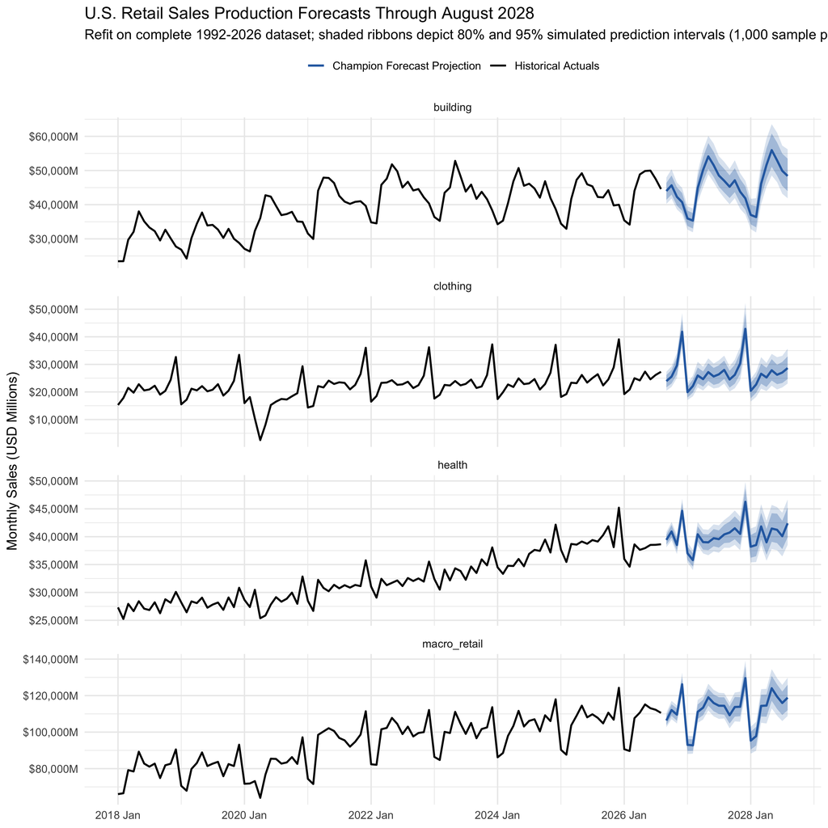

```r
# Generate calendar regressors for the next 24 months (Sep 2026 - Aug 2028)
future_new_data <- new_data(retail_ts, n = 24) |>
  add_trading_days()

# Refit champion specifications on the entire 416-month dataset
production_fits <- retail_ts |>
  model(
    ets_auto   = ETS(sales_nominal),
    arima_auto = ARIMA(log(sales_nominal)),
    arimax_td  = ARIMA(log(sales_nominal) ~ td_mon + td_tue + td_wed + td_thu + td_fri + td_sat + days_in_month),
    tslm_log   = TSLM(log(sales_nominal) ~ trend() + season())
  ) |>
  mutate(
    ens_ets_arimax     = (ets_auto + arimax_td) / 2,
    ens_ets_arima_tslm = (ets_auto + arima_auto + tslm_log) / 3
  )

# Select each vertical's designated champion model
champion_specs <- tibble(
  vertical = c("building", "clothing", "health", "macro_retail"),
  champion_model = c("ens_ets_arima_tslm", "ets_auto", "arimax_td", "ens_ets_arimax")
)

# Extract analytical point forecasts from the refitted models
fc_production <- production_fits |>
  forecast(new_data = future_new_data)

point_fc <- fc_production |>
  as_tibble() |>
  inner_join(champion_specs, by = "vertical") |>
  filter(.model == champion_model) |>
  select(vertical, champion_model, Month, .mean)

# Simulate 1,000 joint sample paths for each constituent model to construct ensemble prediction intervals
# (Analytical convolution is mathematically intractable across transformed log-ARIMA and multiplicative ETS)
set.seed(506)
sim_paths <- production_fits |>
  select(vertical, ets_auto, arima_auto, arimax_td, tslm_log) |>
  generate(new_data = future_new_data, times = 1000) |>
  as_tibble() |>
  select(vertical, .model, Month, .rep, .sim) |>
  pivot_wider(names_from = .model, values_from = .sim) |>
  mutate(
    ens_ets_arimax     = (ets_auto + arimax_td) / 2,
    ens_ets_arima_tslm = (ets_auto + arima_auto + tslm_log) / 3
  )

sim_intervals <- sim_paths |>
  pivot_longer(cols = c(ets_auto, arima_auto, arimax_td, tslm_log, ens_ets_arimax, ens_ets_arima_tslm),
               names_to = ".model", values_to = "sim_val") |>
  inner_join(champion_specs, by = "vertical") |>
  filter(.model == champion_model) |>
  group_by(vertical, champion_model, Month) |>
  summarise(
    `80%_lower` = quantile(sim_val, 0.10, na.rm = TRUE),
    `80%_upper` = quantile(sim_val, 0.90, na.rm = TRUE),
    `95%_lower` = quantile(sim_val, 0.025, na.rm = TRUE),
    `95%_upper` = quantile(sim_val, 0.975, na.rm = TRUE),
    .groups = "drop"
  )

fc_intervals <- point_fc |>
  left_join(sim_intervals, by = c("vertical", "champion_model", "Month"))

# Plot historical trajectory + 24-month champion forecast envelope
ggplot() +
  geom_ribbon(data = fc_intervals, aes(Month, ymin = `95%_lower`, ymax = `95%_upper`), fill = "#2b6cb0", alpha = 0.18) +
  geom_ribbon(data = fc_intervals, aes(Month, ymin = `80%_lower`, ymax = `80%_upper`), fill = "#2b6cb0", alpha = 0.30) +
  geom_line(data = retail_ts |> as_tibble() |> filter(Month >= yearmonth("2018 Jan")),
            aes(Month, sales_nominal, colour = "Historical Actuals"), linewidth = 0.8) +
  geom_line(data = fc_intervals, aes(Month, .mean, colour = "Champion Forecast Projection"), linewidth = 0.9) +
  facet_wrap(vars(vertical), scales = "free_y", ncol = 1) +
  scale_y_continuous(labels = dollar_format(suffix = "M")) +
  scale_colour_manual(values = c("Historical Actuals" = "black", "Champion Forecast Projection" = "#2b6cb0"), name = NULL) +
  labs(title = "U.S. Retail Sales Production Forecasts Through August 2028",
       subtitle = "Refit on complete 1992-2026 dataset; shaded ribbons depict 80% and 95% simulated prediction intervals (1,000 sample paths)",
       y = "Monthly Sales (USD Millions)", x = NULL) +
  theme(legend.position = "top")
```

### 5.7.8 Annual Projected Retail Sales Projections (2025–2027)

To support executive budgeting and strategic inventory purchasing, the table below synthesizes realized historical actuals with out-of-sample model projections.

> **Important Horizon Note on 2026:** Because the historical FRED dataset utilized in this project extends through **August 2026** (416 historical observations), the year 2026 is presented as a **transparent blended projection**:
> - **Realized Historical Actuals (Jan–Aug 2026, 8 months):** Reflects known consumer expenditure reported by the U.S. Census Bureau.
> - **Champion Model Forecast (Sep–Dec 2026, 4 months):** Projects the critical Q4 holiday retail surge.
> - **2026 Blended Total:** Combines realized YTD actuals with our Q4 forecast to provide a complete 12-month calendar estimate.
> - **2027 Full-Year Forecast:** Represents the first 100% forward-looking, out-of-sample projection year.

```r
# 1. Realized full-year 2025 actuals
act_2025 <- retail_ts |>
  as_tibble() |>
  filter(year(Month) == 2025) |>
  group_by(vertical) |>
  summarise(`2025 Actuals` = round(sum(sales_nominal) / 1000, 2))

# 2. Realized 2026 YTD actuals (Jan - Aug, 8 months)
act_2026_8m <- retail_ts |>
  as_tibble() |>
  filter(year(Month) == 2026) |>
  group_by(vertical) |>
  summarise(`2026 YTD Actuals (Jan-Aug)` = round(sum(sales_nominal) / 1000, 2))

# 3. Model Q4 2026 forecast (Sep - Dec, 4 months)
fc_2026_4m <- fc_intervals |>
  filter(year(Month) == 2026) |>
  group_by(vertical) |>
  summarise(`2026 Q4 Forecast (Sep-Dec)` = round(sum(.mean) / 1000, 2))

# 4. Model full-year 2027 forecast (Jan - Dec, 12 months)
fc_2027_12m <- fc_intervals |>
  filter(year(Month) == 2027) |>
  group_by(vertical) |>
  summarise(`2027 Full-Year Forecast` = round(sum(.mean) / 1000, 2))

# 5. Synthesize blended annual table with YoY growth trajectories
annual_projections <- act_2025 |>
  left_join(act_2026_8m, by = "vertical") |>
  left_join(fc_2026_4m, by = "vertical") |>
  mutate(`2026 Blended Total` = round(`2026 YTD Actuals (Jan-Aug)` + `2026 Q4 Forecast (Sep-Dec)`, 2)) |>
  left_join(fc_2027_12m, by = "vertical") |>
  mutate(
    `2026 YoY Growth` = scales::percent((`2026 Blended Total` / `2025 Actuals`) - 1, accuracy = 0.1),
    `2027 YoY Growth` = scales::percent((`2027 Full-Year Forecast` / `2026 Blended Total`) - 1, accuracy = 0.1)
  )

annual_projections |>
  knitr::kable(caption = "Annual U.S. Retail Sales Projections (Billions USD): Realized 2025 Actuals vs. 2026 Blended Total and 2027 Full-Year Forecast")
```

Annual U.S. Retail Sales Projections (Billions USD): Realized 2025 Actuals vs. 2026 Blended Total and 2027 Full-Year Forecast

| vertical | 2025 Actuals | 2026 YTD Actuals (Jan-Aug) | 2026 Q4 Forecast (Sep-Dec) | 2026 Blended Total | 2027 Full-Year Forecast | 2026 YoY Growth | 2027 YoY Growth |
| --- | --- | --- | --- | --- | --- | --- | --- |
| building | 505.26 | 354.44 | 172.70 | 527.14 | 545.64 | 4.3% | 3.5% |
| clothing | 299.90 | 194.70 | 120.94 | 315.64 | 323.83 | 5.2% | 2.6% |
| health | 472.27 | 300.55 | 163.51 | 464.06 | 479.99 | -1.7% | 3.4% |
| macro_retail | 1277.42 | 849.70 | 454.21 | 1303.91 | 1340.76 | 2.1% | 2.8% |

# 6 Executive Summary & Strategic Takeaways for Presentation (Deliverable 1)

# 7 Future Modeling Extensions & Next Steps (Module 6 & Beyond)

To extend the scope of this project beyond classical statistical models, the following advanced methods represent high-leverage next steps:

1. **Machine Learning Ensembles (XGBoost):** Integrating gradient boosted decision trees (`xgboost` / `tidymodels`) with non-linear lagged feature engineering, rolling window summaries, and holiday calendars to capture complex retail interactions.
2. **Zero-Shot Foundation Models (TimeGPT & Chronos):** Benchmarking pre-trained transformer time series foundation models against our classical champions for multi-horizon demand forecasting without local parameter estimation.
3. **Optimal Hierarchical Reconciliation (MinT):** Applying Minimum Trace optimal forecast reconciliation (Hyndman & Athanasopoulos, 2021, Ch. 11) to guarantee that individual sector forecasts sum additively and coherently to the aggregate Macro Retail total.

# 8 Recommended FRED Datasets for Future ARIMAX Models

To enhance explanatory power and evaluate dynamic regressions, the following FRED series are recommended:

1. **Real Disposable Personal Income (`DSPIC96`):** Measures household real disposable income in billions of chained 2017 dollars (Monthly). Captures purchasing power shifts.
2. **Civilian Unemployment Rate (`UNRATE`):** Primary indicator of labor market slack and economic contraction (Monthly, %).
3. **University of Michigan: Consumer Sentiment (`UMCSENT`):** Leading gauge of household consumer confidence, highly correlated with discretionary retail spending.

# 9 Scholarly References (APA 7)

- **Fildes, R., Ma, S., & Kolassa, S. (2022).** Retail forecasting: Research and practice. *International Journal of Forecasting*, 38(4), 1283–1318. https://doi.org/10.1016/j.ijforecast.2019.06.004
- **Hyndman, R. J., & Athanasopoulos, G. (2021).** *Forecasting: Principles and practice* (3rd ed.). OTexts: Melbourne, Australia. https://otexts.com/fpp3/
- **Makridakis, S., Spiliotis, E., & Assimakopoulos, V. (2022).** M5 accuracy competition: Results, findings, and conclusions. *International Journal of Forecasting*, 38(4), 1346–1364. https://doi.org/10.1016/j.ijforecast.2021.11.013